# Categorical - Assignment 1 (correlated data)

Author

Hazlienor

Published

May 26, 2024

**GET502 Analisa Data Kategorikal Lanjutan (Advanced Categorical Data Analysis)**

Assignment 1: Correlated Data for Categorical Outcome

**Report Prepared By**

1. Hazlienor Binti Mohd Hatta 22307055

2. Amalina Binti Asmail @ Ismail 22307044

3. Mohamad Afiq Amsyar Bin Hamedin 23100003

4. Muhammad Saufi bin Abdullah 22307048

5. Tiong Wen Ning 22307078

## Background

What are the factors associated with post-myocardial infarction (post-MI) mortality among patients admitted to hospitals in XX state?

### Description of the Dataset

The dataset consists of data from 1250 patients who experienced a myocardial infarction (MI) and were recruited from 7 different hospitals within a state. The dataset captures variables, with the goal of identifying risk factors associated with post-MI mortality.

**Risk Factor**

- **ID:** ID of patient
- **Hospital:** hospital to which the patient get admitted (1-7)
- **Age (age):** Continuous variable representing the age of the patient in years.
- **Sex (sex):** Categorical variable representing the sex of the patient (Female = 0, Male = 1).
- **Diabetes Status (dm):** Binary variable indicating whether the patient has diabetes (Yes = 1, No = 0).
- **Underlying Hypertension (hpt):** Binary variable indicating whether the patient has hypertension (Yes = 1, No = 0).
- **Chronic Kidney Disease (ckd):** Binary variable indicating whether the patient has chronic kidney disease (Yes = 1, No = 0).
- **Duration of Admission (dur_adm):** Continuous variable representing the length of hospital stay in days.
- **Type of Treatments received (treatment):** Categorical variable indicating the types of treatments received at each hospital (invasive, noninvasive).

**Outcome variable**

- **Post-MI Mortality:** Binary variable indicating the survival status of the patient at discharge (alive = 0, dead = 1).

## Workflow

1. prepare environment
2. load data
3. data exploration and wrangling
4. descriptive analysis
5. univariate analysis
6. multilevel analysis

   estimate

   inference

   prediction
7. data presentation and interpretation

## Prepare environment

```r
library(tidyverse)
```

```
✖ purrr::%||%()   masks base::%||%()
```

```r
library(readxl)
library(aplore3)
library(summarytools)
library(broom.mixed)
library(gee)
library(lme4)
library(sjPlot)
library(kableExtra)
library(gtsummary)
library(reshape2)
```

## Load data

```r
data <-read_xlsx("mi_mortality.xlsx")
```

## Data exploration and wrangling

```r
str(data)
```

```
tibble [1,250 × 10] (S3: tbl_df/tbl/data.frame)
 $ ID       : num [1:1250] 1001 1002 1003 1004 1005 ...
 $ hospital : num [1:1250] 1 1 1 1 1 1 1 1 1 1 ...
 $ age      : num [1:1250] 36 41 43 31 49 56 30 39 42 45 ...
 $ sex      : chr [1:1250] "female" "male" "male" "male" ...
 $ treatment: chr [1:1250] "invasive" "noninvasive" "noninvasive" "noninvasive" ...
 $ dm       : chr [1:1250] "no" "yes" "no" "no" ...
 $ hpt      : chr [1:1250] "no" "no" "yes" "yes" ...
 $ ckd      : chr [1:1250] "no" "no" "no" "no" ...
 $ dur_adm  : num [1:1250] 0 0 0 1 1 1 2 3 3 3 ...
 $ status   : num [1:1250] 0 0 0 0 0 1 0 0 0 0 ...
```

```r
data <- data %>% mutate_if(is.character, as.factor)
data <- data %>% mutate(status = as.factor(status))
```

```r
summary(data)
```

```
       ID          hospital          age            sex            treatment
 Min.   :1001   Min.   :1.000   Min.   :29.00   female:480   invasive   : 125
 1st Qu.:2145   1st Qu.:2.000   1st Qu.:40.00   male  :770   noninvasive:1125
 Median :4098   Median :4.000   Median :45.00
 Mean   :4191   Mean   :4.101   Mean   :46.62
 3rd Qu.:6075   3rd Qu.:6.000   3rd Qu.:51.00
 Max.   :7221   Max.   :7.000   Max.   :74.00
   dm       hpt       ckd         dur_adm       status
 no :548   no :678   no :674   Min.   : 0.000   0:902
 yes:702   yes:572   yes:576   1st Qu.: 3.000   1:348
                               Median : 5.000
                               Mean   : 6.033
                               3rd Qu.: 9.000
                               Max.   :16.000
```

visualize hierarchical tree

```r
library(data.tree)
```

```r
root <- Node$new("Hospitals")
```

```r
patient_counts <- data %>%
  group_by(hospital) %>%
  summarize(patient_count = n())
```

```r
for(i in 1:nrow(patient_counts)) {
  hospital_id <- patient_counts$hospital[i]
  patient_count <- patient_counts$patient_count[i]
  root$AddChild(paste("Hospital", hospital_id, "- Patients:", patient_count))
}
print(root)
```

```
                       levelName
1 Hospitals
2  ¦--Hospital 1 - Patients: 168
3  ¦--Hospital 2 - Patients: 176
4  ¦--Hospital 3 - Patients: 184
5  ¦--Hospital 4 - Patients: 164
6  ¦--Hospital 5 - Patients: 171
7  ¦--Hospital 6 - Patients: 166
8  °--Hospital 7 - Patients: 221
```

## Descriptive and univariate analysis

```r
data %>%
  select(-ID) %>%
  tbl_summary(by = status,
            statistic = list(all_continuous() ~ "{mean} ({sd})"),
            digits = age ~ c(1, 1)
             ) %>%
            modify_header(update = list(stat_1 ~ "**Alive**",
                                        stat_2 ~ "**Dead**")) %>%
            add_overall() %>%
            add_p
```

| **Characteristic** | **Overall**, N = 1,250<sup>1</sup> | **Alive**<sup>1</sup> | **Dead**<sup>1</sup> | **p-value**<sup>2</sup> |
| --- | --- | --- | --- | --- |
| hospital |  |  |  | <0.001 |
| 1 | 168 (13%) | 138 (15%) | 30 (8.6%) |  |
| 2 | 176 (14%) | 122 (14%) | 54 (16%) |  |
| 3 | 184 (15%) | 104 (12%) | 80 (23%) |  |
| 4 | 164 (13%) | 128 (14%) | 36 (10%) |  |
| 5 | 171 (14%) | 129 (14%) | 42 (12%) |  |
| 6 | 166 (13%) | 124 (14%) | 42 (12%) |  |
| 7 | 221 (18%) | 157 (17%) | 64 (18%) |  |
| age | 46.6 (9.4) | 44.2 (7.6) | 53.0 (10.7) | <0.001 |
| sex |  |  |  | <0.001 |
| female | 480 (38%) | 378 (42%) | 102 (29%) |  |
| male | 770 (62%) | 524 (58%) | 246 (71%) |  |
| treatment |  |  |  | <0.001 |
| invasive | 125 (10%) | 109 (12%) | 16 (4.6%) |  |
| noninvasive | 1,125 (90%) | 793 (88%) | 332 (95%) |  |
| dm | 702 (56%) | 440 (49%) | 262 (75%) | <0.001 |
| hpt | 572 (46%) | 406 (45%) | 166 (48%) | 0.4 |
| ckd | 576 (46%) | 365 (40%) | 211 (61%) | <0.001 |
| dur_adm | 6.0 (4.0) | 5.2 (3.4) | 8.2 (4.4) | <0.001 |

<sup>1</sup> n (%); Mean (SD)  
<sup>2</sup> Pearson’s Chi-squared test; Wilcoxon rank sum test

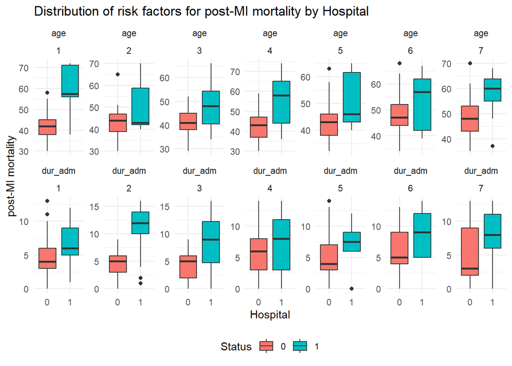

```r
library(reshape2)
eda <- melt(data[, c("status", "age", "dur_adm", "hospital")],
            id.vars = c("status", "hospital"))


ggplot(eda, aes(factor(status), y = value, fill = factor(status))) +
  geom_boxplot() +
  facet_wrap(~ variable + hospital, scales = "free_y", ncol = 7) +
  labs(x = "Hospital", y = "post-MI mortality", fill = "Status") +
  theme_minimal() +
  theme(legend.position = "bottom") +
  ggtitle("Distribution of risk factors for post-MI mortality by Hospital")
```

```r
prop_sex <- data %>%
  group_by(hospital, sex) %>%
  summarize(prop_status = mean(as.numeric(status) - 1), .groups = 'drop')
```

```r
plotsex <- ggplot(prop_sex, aes(x = sex, y = prop_status, group = hospital, color = as.factor(hospital))) +
  geom_line(linetype = "solid", color = "black",linewidth = 1, show.legend = FALSE) +
  coord_cartesian(ylim = c(0, 0.6)) +
  scale_y_continuous(breaks = seq(0, 1, by = 0.2), labels = scales::percent_format(accuracy = 1)) +
  ylab("% Post-MI mortality") +
  xlab("Sex") +
   theme_minimal() +
  theme(legend.title = element_blank())
```

```r
prop_dm <- data %>%
  group_by(hospital, dm) %>%
  summarize(prop_status = mean(as.numeric(status) - 1), .groups = 'drop')
```

```r
plotdm <- ggplot(prop_sex, aes(x = sex, y = prop_status, group = hospital, color = as.factor(hospital))) +
  geom_line(linetype = "solid", color = "black",linewidth = 1, show.legend = FALSE) +
  coord_cartesian(ylim = c(0, 0.6)) +
  scale_y_continuous(breaks = seq(0, 1, by = 0.2), labels = scales::percent_format(accuracy = 1)) +
  xlab("Diabetes Mellitus") +
  theme_minimal() +
  theme(legend.title = element_blank(),
        axis.text.y = element_blank(),
        axis.title.y = element_blank())
```

```r
prop_ckd <- data %>%
  group_by(hospital, ckd) %>%
  summarize(prop_status = mean(as.numeric(status) - 1), .groups = 'drop')
```

```r
plotckd <- ggplot(prop_ckd, aes(x = ckd, y = prop_status, group = hospital, color = as.factor(hospital))) +
  geom_line(linetype = "solid", color = "black",linewidth = 1, show.legend = FALSE) +
  coord_cartesian(ylim = c(0, 0.6)) +
  scale_y_continuous(breaks = seq(0, 1, by = 0.2), labels = scales::percent_format(accuracy = 1)) +
  ylab("% Post-MI mortality") +
  xlab("Sex") +
   theme_minimal() +
  theme(legend.title = element_blank())
```

```r
prop_tx <- data %>%
  group_by(hospital, treatment) %>%
  summarize(prop_status = mean(as.numeric(status) - 1), .groups = 'drop')
```

```r
plottx <- ggplot(prop_tx, aes(x = treatment, y = prop_status, group = hospital, color = as.factor(hospital))) +
  geom_line(linetype = "solid", color = "black",linewidth = 1) +
  coord_cartesian(ylim = c(0, 0.6)) +
  scale_y_continuous(breaks = seq(0, 1, by = 0.2), labels = scales::percent_format(accuracy = 1)) +
  xlab("type of treatment") +
  theme_minimal() +
  scale_color_brewer(palette="Dark2") +
  theme(legend.title = element_blank(),
        axis.text.y = element_blank(),
        axis.title.y = element_blank())
```

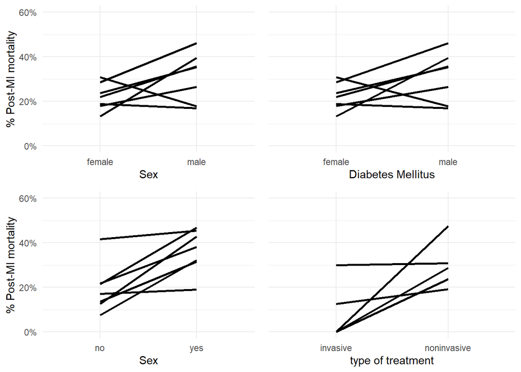

```r
library(gridExtra)
grid.arrange(plotsex, plotdm, plotckd, plottx, ncol = 2)
```

## Multivariate analysis (model building)

**Fixed effect and random effect**

Variable included in the model building : independent variable (age, sex, dm, ckd, treatment, dur_adm), outcome variable (status)

** Model building and Estimation**

### Binary logistic regression model

```r
mlog_model <- glm(status ~ age + sex + dm + ckd + treatment + dur_adm, family = binomial(link = 'logit'), data = data)
summary(mlog_model)
```

```
Call:
glm(formula = status ~ age + sex + dm + ckd + treatment + dur_adm,
    family = binomial(link = "logit"), data = data)

Coefficients:
                      Estimate Std. Error z value Pr(>|z|)
(Intercept)          -11.72011    0.72094 -16.257  < 2e-16 ***
age                    0.13970    0.01046  13.359  < 2e-16 ***
sexmale                1.21216    0.18462   6.566 5.18e-11 ***
dmyes                  0.85874    0.17596   4.880 1.06e-06 ***
ckdyes                 1.06252    0.17306   6.140 8.28e-10 ***
treatmentnoninvasive   0.66656    0.32820   2.031   0.0423 *
dur_adm                0.23033    0.02115  10.889  < 2e-16 ***
---
Signif. codes:  0 '***' 0.001 '**' 0.01 '*' 0.05 '.' 0.1 ' ' 1

(Dispersion parameter for binomial family taken to be 1)

    Null deviance: 1478.6  on 1249  degrees of freedom
Residual deviance:  965.3  on 1243  degrees of freedom
AIC: 979.3

Number of Fisher Scoring iterations: 5
```

There are one possible sources of correlation between observations in the data - on the study site (hospital).

As subjects (level 1) are clustered within hospital (level 2) it may be necessary to consider a two-level random effects model when analyzing the data.

### Marginal (population average) model

```r
gee_model<- gee(status ~ age + sex +dm + ckd + treatment + dur_adm, id = hospital,
                data = data, family = binomial(link = 'logit'),
                corstr = "independence",
                scale.fix = TRUE, scale.value = 1,
                maxiter = 100)
```

```
Beginning Cgee S-function, @(#) geeformula.q 4.13 98/01/27
```

```
running glm to get initial regression estimate
```

```
         (Intercept)                  age              sexmale
         -11.7201143            0.1396963            1.2121598
               dmyes               ckdyes treatmentnoninvasive
           0.8587351            1.0625248            0.6665566
             dur_adm
           0.2303253
```

summary of estimates

```r
sum_gee_model <- data.frame(log_odds = coef(gee_model),
                           odds_ratio = exp(coef(gee_model)))
sum_gee_model
```

```
                        log_odds   odds_ratio
(Intercept)          -11.7201144 8.128661e-06
age                    0.1396963 1.149924e+00
sexmale                1.2121598 3.360735e+00
dmyes                  0.8587351 2.360173e+00
ckdyes                 1.0625248 2.893668e+00
treatmentnoninvasive   0.6665566 1.947520e+00
dur_adm                0.2303253 1.259010e+00
```

### Conditional model

#### Random intercept

random intercept (hospital)

```r
ri_lme <- glmer(status ~ age + sex + dm + ckd + treatment + dur_adm +
                        (1 | hospital), family = binomial, nAGQ = 20,
                      data = data)
summary(ri_lme)
```

```
Generalized linear mixed model fit by maximum likelihood (Adaptive
  Gauss-Hermite Quadrature, nAGQ = 20) [glmerMod]
 Family: binomial  ( logit )
Formula: status ~ age + sex + dm + ckd + treatment + dur_adm + (1 | hospital)
   Data: data

     AIC      BIC   logLik deviance df.resid
   922.3    963.3   -453.1    906.3     1242

Scaled residuals:
    Min      1Q  Median      3Q     Max
-1.6885 -0.4087 -0.1890  0.2284  8.9405

Random effects:
 Groups   Name        Variance Std.Dev.
 hospital (Intercept) 0.5685   0.754
Number of obs: 1250, groups:  hospital, 7

Fixed effects:
                      Estimate Std. Error z value Pr(>|z|)
(Intercept)          -13.30323    0.87227 -15.251  < 2e-16 ***
age                    0.16044    0.01177  13.625  < 2e-16 ***
sexmale                1.03416    0.20038   5.161 2.46e-07 ***
dmyes                  1.11330    0.18896   5.892 3.82e-09 ***
ckdyes                 1.13530    0.18321   6.197 5.77e-10 ***
treatmentnoninvasive   0.98851    0.35449   2.789   0.0053 **
dur_adm                0.25179    0.02330  10.808  < 2e-16 ***
---
Signif. codes:  0 '***' 0.001 '**' 0.01 '*' 0.05 '.' 0.1 ' ' 1

Correlation of Fixed Effects:
            (Intr) age    sexmal dmyes  ckdyes trtmnt
age         -0.791
sexmale     -0.372  0.258
dmyes       -0.208  0.122 -0.061
ckdyes      -0.311  0.218  0.100 -0.142
trtmntnnnvs -0.398 -0.022  0.055 -0.013  0.097
dur_adm     -0.464  0.295  0.116  0.058  0.167  0.089
```

#### Random intercept with single random slope

Estimating the fixed effect of the risk factors while also controlling for random effect of duration of admission (slope) and hospital (intercept)

```r
rs_lme_dur <- glmer(status ~ age + sex + dm + ckd + dur_adm +
                        (1 + dur_adm| hospital), family = binomial("logit"), data = data, glmerControl(calc.derivs = FALSE))
summary(rs_lme_dur)
```

```
Generalized linear mixed model fit by maximum likelihood (Laplace
  Approximation) [glmerMod]
 Family: binomial  ( logit )
Formula: status ~ age + sex + dm + ckd + dur_adm + (1 + dur_adm | hospital)
   Data: data
Control: glmerControl(calc.derivs = FALSE)

     AIC      BIC   logLik deviance df.resid
   913.0    959.1   -447.5    895.0     1241

Scaled residuals:
    Min      1Q  Median      3Q     Max
-1.4587 -0.4021 -0.1904  0.1889 12.2119

Random effects:
 Groups   Name        Variance Std.Dev. Corr
 hospital (Intercept) 0.001494 0.03865
          dur_adm     0.011214 0.10590  1.00
Number of obs: 1250, groups:  hospital, 7

Fixed effects:
             Estimate Std. Error z value Pr(>|z|)
(Intercept) -12.63163    0.75369 -16.760  < 2e-16 ***
age           0.16472    0.01169  14.096  < 2e-16 ***
sexmale       1.11335    0.20083   5.544 2.96e-08 ***
dmyes         1.18565    0.19143   6.194 5.88e-10 ***
ckdyes        1.13265    0.18303   6.188 6.09e-10 ***
dur_adm       0.24625    0.04667   5.277 1.32e-07 ***
---
Signif. codes:  0 '***' 0.001 '**' 0.01 '*' 0.05 '.' 0.1 ' ' 1

Correlation of Fixed Effects:
        (Intr) age    sexmal dmyes  ckdyes
age     -0.935
sexmale -0.462  0.337
dmyes   -0.267  0.136 -0.049
ckdyes  -0.318  0.213  0.074 -0.109
dur_adm -0.233  0.146  0.052  0.040  0.091
```

#### Random intercept with multiple random slope

Estimating the fixed effect of the risk factors while controlling for random effect of duration of admission (slope), treatment (slope), and hospital (intercept)

```r
rs_lme_dur_tx <- glmer(status ~ age + sex + dm + ckd + dur_adm + treatment +
                        (1 + dur_adm + treatment | hospital), family = binomial("logit"), data = data, glmerControl(calc.derivs = FALSE))
summary(rs_lme_dur_tx)
```

```
Generalized linear mixed model fit by maximum likelihood (Laplace
  Approximation) [glmerMod]
 Family: binomial  ( logit )
Formula: status ~ age + sex + dm + ckd + dur_adm + treatment + (1 + dur_adm +
    treatment | hospital)
   Data: data
Control: glmerControl(calc.derivs = FALSE)

     AIC      BIC   logLik deviance df.resid
   897.6    964.3   -435.8    871.6     1237

Scaled residuals:
    Min      1Q  Median      3Q     Max
-1.4932 -0.3851 -0.1643  0.1808 13.9685

Random effects:
 Groups   Name                 Variance Std.Dev. Corr
 hospital (Intercept)          4.60092  2.1450
          dur_adm              0.01332  0.1154   -0.44
          treatmentnoninvasive 5.89280  2.4275   -1.00  0.38
Number of obs: 1250, groups:  hospital, 7

Fixed effects:
                      Estimate Std. Error z value Pr(>|z|)
(Intercept)          -14.27272    1.35535 -10.531  < 2e-16 ***
age                    0.16772    0.01215  13.807  < 2e-16 ***
sexmale                1.17931    0.20963   5.626 1.85e-08 ***
dmyes                  1.09413    0.19641   5.571 2.54e-08 ***
ckdyes                 1.21912    0.18984   6.422 1.35e-10 ***
dur_adm                0.25542    0.05032   5.076 3.86e-07 ***
treatmentnoninvasive   1.45345    1.21591   1.195    0.232
---
Signif. codes:  0 '***' 0.001 '**' 0.01 '*' 0.05 '.' 0.1 ' ' 1

Correlation of Fixed Effects:
            (Intr) age    sexmal dmyes  ckdyes dur_dm
age         -0.492
sexmale     -0.284  0.340
dmyes       -0.117  0.109 -0.040
ckdyes      -0.211  0.222  0.109 -0.122
dur_adm     -0.386  0.145  0.072  0.043  0.097
trtmntnnnvs -0.814 -0.055  0.007 -0.029  0.021  0.268
```

### Model comparison

We compare the AIC of binary logistic regression to random intercept model, random intercept with single random slope model, and random intercept with multiple random slopes model.

```r
models <- list(mlog_model, ri_lme, rs_lme_dur, rs_lme_dur_tx)
extract_aic <- function(model) {
  return(AIC(model))
}
aic_values <- sapply(models, extract_aic)

# Name the AIC values for easy identification
names(aic_values) <- c("mlog", "random intercept", "random intercept single slope", "random intercept multiple slope")

# Print the AIC values
print(aic_values)
```

```
                           mlog                random intercept
                       979.3010                        922.2822
  random intercept single slope random intercept multiple slope
                       912.9651                        897.5587
```

The AIC of random effect model was lower than the binary logistic regression model, hence inclusion of random effect is justified.

compare random intercept to random intercept with single slope

```r
anova(ri_lme, rs_lme_dur, test = 'Chisq')
```

```
Data: data
Models:
ri_lme: status ~ age + sex + dm + ckd + treatment + dur_adm + (1 | hospital)
rs_lme_dur: status ~ age + sex + dm + ckd + dur_adm + (1 + dur_adm | hospital)
           npar    AIC    BIC  logLik deviance  Chisq Df Pr(>Chisq)
ri_lme        8 922.28 963.33 -453.14   906.28
rs_lme_dur    9 912.97 959.14 -447.48   894.97 11.317  1   0.000768 ***
---
Signif. codes:  0 '***' 0.001 '**' 0.01 '*' 0.05 '.' 0.1 ' ' 1
```

compare random intercept with single slope to random intercept with multiple slope

```r
anova(rs_lme_dur, rs_lme_dur_tx, test = 'Chisq')
```

```
Data: data
Models:
rs_lme_dur: status ~ age + sex + dm + ckd + dur_adm + (1 + dur_adm | hospital)
rs_lme_dur_tx: status ~ age + sex + dm + ckd + dur_adm + treatment + (1 + dur_adm + treatment | hospital)
              npar    AIC    BIC  logLik deviance  Chisq Df Pr(>Chisq)
rs_lme_dur       9 912.97 959.14 -447.48   894.97
rs_lme_dur_tx   13 897.56 964.26 -435.78   871.56 23.406  4   0.000105 ***
---
Signif. codes:  0 '***' 0.001 '**' 0.01 '*' 0.05 '.' 0.1 ' ' 1
```

The AIC of random intercept with multiple random slope model was significantly smaller than other random effect model, hence it is selected as the preliminary final model.

#### Estimate

preliminary final model

```r
rs_lme_dur_tx <- glmer(status ~ age + sex + dm + ckd + dur_adm + treatment +
                        (1 + dur_adm + treatment | hospital), family = binomial("logit"), data = data, glmerControl(calc.derivs = FALSE))
summary(rs_lme_dur_tx)
```

```
Generalized linear mixed model fit by maximum likelihood (Laplace
  Approximation) [glmerMod]
 Family: binomial  ( logit )
Formula: status ~ age + sex + dm + ckd + dur_adm + treatment + (1 + dur_adm +
    treatment | hospital)
   Data: data
Control: glmerControl(calc.derivs = FALSE)

     AIC      BIC   logLik deviance df.resid
   897.6    964.3   -435.8    871.6     1237

Scaled residuals:
    Min      1Q  Median      3Q     Max
-1.4932 -0.3851 -0.1643  0.1808 13.9685

Random effects:
 Groups   Name                 Variance Std.Dev. Corr
 hospital (Intercept)          4.60092  2.1450
          dur_adm              0.01332  0.1154   -0.44
          treatmentnoninvasive 5.89280  2.4275   -1.00  0.38
Number of obs: 1250, groups:  hospital, 7

Fixed effects:
                      Estimate Std. Error z value Pr(>|z|)
(Intercept)          -14.27272    1.35535 -10.531  < 2e-16 ***
age                    0.16772    0.01215  13.807  < 2e-16 ***
sexmale                1.17931    0.20963   5.626 1.85e-08 ***
dmyes                  1.09413    0.19641   5.571 2.54e-08 ***
ckdyes                 1.21912    0.18984   6.422 1.35e-10 ***
dur_adm                0.25542    0.05032   5.076 3.86e-07 ***
treatmentnoninvasive   1.45345    1.21591   1.195    0.232
---
Signif. codes:  0 '***' 0.001 '**' 0.01 '*' 0.05 '.' 0.1 ' ' 1

Correlation of Fixed Effects:
            (Intr) age    sexmal dmyes  ckdyes dur_dm
age         -0.492
sexmale     -0.284  0.340
dmyes       -0.117  0.109 -0.040
ckdyes      -0.211  0.222  0.109 -0.122
dur_adm     -0.386  0.145  0.072  0.043  0.097
trtmntnnnvs -0.814 -0.055  0.007 -0.029  0.021  0.268
```

#### Inference

##### log odds

```r
tidy(rs_lme_dur_tx, conf.int=T)
```

```
# A tibble: 13 × 9
   effect  group term  estimate std.error statistic   p.value conf.low conf.high
   <chr>   <chr> <chr>    <dbl>     <dbl>     <dbl>     <dbl>    <dbl>     <dbl>
 1 fixed   <NA>  (Int…  -14.3      1.36      -10.5   6.24e-26  -16.9     -11.6
 2 fixed   <NA>  age      0.168    0.0121     13.8   2.31e-43    0.144     0.192
 3 fixed   <NA>  sexm…    1.18     0.210       5.63  1.85e- 8    0.768     1.59
 4 fixed   <NA>  dmyes    1.09     0.196       5.57  2.54e- 8    0.709     1.48
 5 fixed   <NA>  ckdy…    1.22     0.190       6.42  1.35e-10    0.847     1.59
 6 fixed   <NA>  dur_…    0.255    0.0503      5.08  3.86e- 7    0.157     0.354
 7 fixed   <NA>  trea…    1.45     1.22        1.20  2.32e- 1   -0.930     3.84
 8 ran_pa… hosp… sd__…    2.14    NA          NA    NA          NA        NA
 9 ran_pa… hosp… cor_…   -0.437   NA          NA    NA          NA        NA
10 ran_pa… hosp… cor_…   -0.998   NA          NA    NA          NA        NA
11 ran_pa… hosp… sd__…    0.115   NA          NA    NA          NA        NA
12 ran_pa… hosp… cor_…    0.385   NA          NA    NA          NA        NA
13 ran_pa… hosp… sd__…    2.43    NA          NA    NA          NA        NA
```

##### odds ratio

```r
tidy(rs_lme_dur_tx, exponentiate=T, conf.int=T)
```

```
# A tibble: 13 × 9
   effect  group term  estimate std.error statistic   p.value conf.low conf.high
   <chr>   <chr> <chr>    <dbl>     <dbl>     <dbl>     <dbl>    <dbl>     <dbl>
 1 fixed   <NA>  (Int…  6.33e-7   8.58e-7    -10.5   6.24e-26  4.44e-8   9.02e-6
 2 fixed   <NA>  age    1.18e+0   1.44e-2     13.8   2.31e-43  1.15e+0   1.21e+0
 3 fixed   <NA>  sexm…  3.25e+0   6.82e-1      5.63  1.85e- 8  2.16e+0   4.90e+0
 4 fixed   <NA>  dmyes  2.99e+0   5.87e-1      5.57  2.54e- 8  2.03e+0   4.39e+0
 5 fixed   <NA>  ckdy…  3.38e+0   6.42e-1      6.42  1.35e-10  2.33e+0   4.91e+0
 6 fixed   <NA>  dur_…  1.29e+0   6.50e-2      5.08  3.86e- 7  1.17e+0   1.42e+0
 7 fixed   <NA>  trea…  4.28e+0   5.20e+0      1.20  2.32e- 1  3.95e-1   4.64e+1
 8 ran_pa… hosp… sd__…  2.14e+0  NA           NA    NA        NA        NA
 9 ran_pa… hosp… cor_… -4.37e-1  NA           NA    NA        NA        NA
10 ran_pa… hosp… cor_… -9.98e-1  NA           NA    NA        NA        NA
11 ran_pa… hosp… sd__…  1.15e-1  NA           NA    NA        NA        NA
12 ran_pa… hosp… cor_…  3.85e-1  NA           NA    NA        NA        NA
13 ran_pa… hosp… sd__…  2.43e+0  NA           NA    NA        NA        NA
```

##### random effects

```r
tidy(rs_lme_dur_tx, effects = 'ran_vals',
     conf.int = TRUE)
```

```
# A tibble: 21 × 8
   effect   group    level term        estimate std.error conf.low conf.high
   <chr>    <chr>    <chr> <chr>          <dbl>     <dbl>    <dbl>     <dbl>
 1 ran_vals hospital 1     (Intercept)   2.02      0.563    0.920     3.13
 2 ran_vals hospital 2     (Intercept)   0.600     0.503   -0.387     1.59
 3 ran_vals hospital 3     (Intercept)  -3.78      1.24    -6.22     -1.35
 4 ran_vals hospital 4     (Intercept)   0.553     1.37    -2.13      3.24
 5 ran_vals hospital 5     (Intercept)  -1.41      0.929   -3.23      0.410
 6 ran_vals hospital 6     (Intercept)   1.66      1.41    -1.10      4.42
 7 ran_vals hospital 7     (Intercept)   0.564     1.24    -1.87      3.00
 8 ran_vals hospital 1     dur_adm      -0.0545    0.0393  -0.132     0.0226
 9 ran_vals hospital 2     dur_adm       0.131     0.0321   0.0679    0.194
10 ran_vals hospital 3     dur_adm       0.204     0.0435   0.119     0.289
# ℹ 11 more rows
```

#### Prediction

##### level 1: subject

```r
augment(rs_lme_dur_tx) %>%
  slice(1:30) %>%
  kbl() %>%
  kable_styling()
```

| status | age | sex | dm | ckd | dur_adm | treatment | hospital | .fitted | .resid | .hat | .cooksd | .fixed | .mu | .offset | .sqrtXwt | .sqrtrwt | .weights | .wtres | .eta |
| --- | --- | --- | --- | --- | --- | --- | --- | --- | --- | --- | --- | --- | --- | --- | --- | --- | --- | --- | --- |
| 0 | 36 | female | no | no | 0 | invasive | 1 | -6.2110437 | -0.0633266 | 0.4382129 | 0.0003981 | -8.2348803 | 0.0020031 | 0 | 0.0447114 | 22.365665 | 1 | -0.0448011 | -6.2110437 |
| 0 | 41 | male | yes | no | 0 | noninvasive | 1 | -3.9230557 | -0.1979266 | 0.1011348 | 0.0003537 | -3.6694113 | 0.0193969 | 0 | 0.1379153 | 7.250826 | 1 | -0.1406434 | -3.9230557 |
| 0 | 43 | male | no | no | 0 | noninvasive | 1 | -4.6817486 | -0.1357952 | 0.1137832 | 0.0001917 | -4.4281041 | 0.0091778 | 0 | 0.0953602 | 10.486560 | 1 | -0.0962435 | -4.6817486 |
| 0 | 31 | male | no | no | 1 | noninvasive | 1 | -6.4934163 | -0.0549950 | 0.1604626 | 0.0000492 | -6.1852933 | 0.0015111 | 0 | 0.0388433 | 25.744484 | 1 | -0.0389021 | -6.4934163 |
| 0 | 49 | male | no | no | 1 | noninvasive | 1 | -3.4744966 | -0.2470114 | 0.0862459 | 0.0004571 | -3.1663735 | 0.0300467 | 0 | 0.1707157 | 5.857692 | 1 | -0.1760040 | -3.4744966 |
| 1 | 56 | male | yes | yes | 1 | noninvasive | 1 | 0.0127804 | 1.1719875 | 0.0629400 | 0.0101098 | 0.3209035 | 0.5031951 | 0 | 0.4999898 | 2.000041 | 1 | 0.9936302 | 0.0127804 |
| 0 | 30 | female | yes | yes | 2 | noninvasive | 1 | -5.3262425 | -0.0984939 | 0.1598208 | 0.0001573 | -4.9636408 | 0.0048388 | 0 | 0.0693928 | 14.410711 | 1 | -0.0697302 | -5.3262425 |
| 0 | 39 | female | yes | yes | 3 | noninvasive | 1 | -3.6158372 | -0.2303871 | 0.1035868 | 0.0004953 | -3.1987569 | 0.0261900 | 0 | 0.1597001 | 6.261738 | 1 | -0.1639951 | -3.6158372 |
| 0 | 42 | female | no | no | 3 | noninvasive | 1 | -5.4259366 | -0.0937154 | 0.1330357 | 0.0001113 | -5.0088563 | 0.0043817 | 0 | 0.0660489 | 15.140293 | 1 | -0.0663396 | -5.4259366 |
| 0 | 45 | male | yes | no | 3 | noninvasive | 1 | -2.6493484 | -0.3696217 | 0.0643799 | 0.0007428 | -2.2322681 | 0.0660292 | 0 | 0.2483331 | 4.026849 | 1 | -0.2658896 | -2.6493484 |
| 0 | 40 | female | yes | yes | 4 | noninvasive | 1 | -3.2471741 | -0.2762137 | 0.1001722 | 0.0006872 | -2.7756151 | 0.0374286 | 0 | 0.1898096 | 5.268439 | 1 | -0.1971901 | -3.2471741 |
| 0 | 36 | male | no | no | 4 | invasive | 1 | -4.2279555 | -0.1701580 | 0.3714302 | 0.0019584 | -6.0338777 | 0.0143726 | 0 | 0.1190211 | 8.401873 | 1 | -0.1207567 | -4.2279555 |
| 0 | 41 | male | yes | yes | 4 | noninvasive | 1 | -1.9001498 | -0.5279532 | 0.0580704 | 0.0013983 | -1.4285909 | 0.1300915 | 0 | 0.3364041 | 2.972615 | 1 | -0.3867121 | -1.9001498 |
| 0 | 45 | male | yes | yes | 4 | noninvasive | 1 | -1.2292787 | -0.7163533 | 0.0522129 | 0.0024288 | -0.7577198 | 0.2263077 | 0 | 0.4184406 | 2.389826 | 1 | -0.5408359 | -1.2292787 |
| 0 | 42 | male | yes | no | 4 | invasive | 1 | -2.1275206 | -0.4744548 | 0.3609880 | 0.0150455 | -3.9334427 | 0.1064506 | 0 | 0.3084135 | 3.242401 | 1 | -0.3451555 | -2.1275206 |
| 0 | 44 | female | no | no | 5 | noninvasive | 1 | -4.6886103 | -0.1353322 | 0.1243354 | 0.0002131 | -4.1625727 | 0.0091156 | 0 | 0.0950395 | 10.521939 | 1 | -0.0959138 | -4.6886103 |
| 1 | 68 | female | yes | no | 9 | noninvasive | 1 | 1.2345261 | 0.7146970 | 0.1668670 | 0.0099930 | 1.9784781 | 0.7746098 | 0 | 0.4178391 | 2.393266 | 1 | 0.5394188 | 1.2345261 |
| 0 | 34 | male | no | yes | 5 | noninvasive | 1 | -3.9673571 | -0.1936314 | 0.1164522 | 0.0004033 | -3.4413196 | 0.0185719 | 0 | 0.1350075 | 7.406997 | 1 | -0.1375623 | -3.9673571 |
| 1 | 72 | female | yes | yes | 5 | noninvasive | 1 | 2.3207398 | 0.4328356 | 0.1284110 | 0.0023714 | 2.8467773 | 0.9105802 | 0 | 0.2853487 | 3.504484 | 1 | 0.3133702 | 2.3207398 |
| 0 | 38 | female | yes | no | 6 | noninvasive | 1 | -4.3998430 | -0.1562337 | 0.1466024 | 0.0003531 | -3.8193269 | 0.0121303 | 0 | 0.1094677 | 9.135117 | 1 | -0.1108119 | -4.3998430 |
| 0 | 30 | female | yes | yes | 2 | noninvasive | 1 | -5.3262425 | -0.0984939 | 0.1598208 | 0.0001573 | -4.9636408 | 0.0048388 | 0 | 0.0693928 | 14.410711 | 1 | -0.0697302 | -5.3262425 |
| 0 | 39 | female | yes | yes | 3 | noninvasive | 1 | -3.6158372 | -0.2303871 | 0.1035868 | 0.0004953 | -3.1987569 | 0.0261900 | 0 | 0.1597001 | 6.261738 | 1 | -0.1639951 | -3.6158372 |
| 0 | 42 | female | no | no | 3 | noninvasive | 1 | -5.4259366 | -0.0937154 | 0.1330357 | 0.0001113 | -5.0088563 | 0.0043817 | 0 | 0.0660489 | 15.140293 | 1 | -0.0663396 | -5.4259366 |
| 1 | 45 | male | yes | no | 7 | noninvasive | 1 | -1.8455668 | 1.9960990 | 0.0911454 | 0.0998085 | -1.2105720 | 0.1363942 | 0 | 0.3432067 | 2.913696 | 1 | 2.5162845 | -1.8455668 |
| 0 | 41 | male | yes | yes | 4 | noninvasive | 1 | -1.9001498 | -0.5279532 | 0.0580704 | 0.0013983 | -1.4285909 | 0.1300915 | 0 | 0.3364041 | 2.972615 | 1 | -0.3867121 | -1.9001498 |
| 0 | 45 | male | yes | yes | 4 | noninvasive | 1 | -1.2292787 | -0.7163533 | 0.0522129 | 0.0024288 | -0.7577198 | 0.2263077 | 0 | 0.4184406 | 2.389826 | 1 | -0.5408359 | -1.2292787 |
| 0 | 42 | male | yes | no | 4 | invasive | 1 | -2.1275206 | -0.4744548 | 0.3609880 | 0.0150455 | -3.9334427 | 0.1064506 | 0 | 0.3084135 | 3.242401 | 1 | -0.3451555 | -2.1275206 |
| 0 | 44 | female | no | no | 5 | noninvasive | 1 | -4.6886103 | -0.1353322 | 0.1243354 | 0.0002131 | -4.1625727 | 0.0091156 | 0 | 0.0950395 | 10.521939 | 1 | -0.0959138 | -4.6886103 |
| 1 | 68 | female | yes | no | 9 | noninvasive | 1 | 1.2345261 | 0.7146970 | 0.1668670 | 0.0099930 | 1.9784781 | 0.7746098 | 0 | 0.4178391 | 2.393266 | 1 | 0.5394188 | 1.2345261 |
| 0 | 34 | male | no | yes | 5 | noninvasive | 1 | -3.9673571 | -0.1936314 | 0.1164522 | 0.0004033 | -3.4413196 | 0.0185719 | 0 | 0.1350075 | 7.406997 | 1 | -0.1375623 | -3.9673571 |

###### predicted log odds

```r
head(predict(rs_lme_dur_tx, type = 'link'), 10)
```

```
          1           2           3           4           5           6
-6.21104370 -3.92305572 -4.68174858 -6.49341633 -3.47449659  0.01278041
          7           8           9          10
-5.32624253 -3.61583724 -5.42593661 -2.64934843
```

log odd (manual) for first observation

```r
data[1,]
```

```
# A tibble: 1 × 10
     ID hospital   age sex    treatment dm    hpt   ckd   dur_adm status
  <dbl>    <dbl> <dbl> <fct>  <fct>     <fct> <fct> <fct>   <dbl> <fct>
1  1001        1    36 female invasive  no    no    no          0 0
```

fixed effect

```r
fixef(rs_lme_dur_tx)
```

```
         (Intercept)                  age              sexmale
         -14.2727198            0.1677178            1.1793065
               dmyes               ckdyes              dur_adm
           1.0941284            1.2191243            0.2554240
treatmentnoninvasive
           1.4534453
```

random effect

```r
head(ranef(rs_lme_dur_tx), 3)
```

```
$hospital
  (Intercept)     dur_adm treatmentnoninvasive
1   2.0238366 -0.05447862           -2.2774811
2   0.5997651  0.13069308           -0.8704736
3  -3.7831399  0.20408397            4.1211749
4   0.5531807 -0.06081919           -0.5613605
5  -1.4110052 -0.07807459            1.7423918
6   1.6583693 -0.08719161           -1.8095738
7   0.5636480 -0.04120093           -0.5996370
```

logit(P(Y_ij =1))=β0+β1Ageij +β2Genderij +β3DMij +β4CKDij +β5 treatmentij+β6dur_admij +u0j + u5treatmentij + u6dur_admij

```r
( -14.2727198)+(0.1677178*36)+(2.0238366)
```

```
[1] -6.211042
```

###### predicted probability

```r
head(predict(rs_lme_dur_tx, type = 'response'), 10)
```

```
          1           2           3           4           5           6
0.002003121 0.019396877 0.009177791 0.001511083 0.030046656 0.503195060
          7           8           9          10
0.004838778 0.026190033 0.004381659 0.066029180
```

probability (manual) - 1st subject

```r
exp(-6.2110437)/(1+exp(-6.2110437))
```

```
[1] 0.002003121
```

##### level 2: hospital

create new data

```r
new_data <- expand.grid(hospital = c(1:7),
                        sex = c('female', 'male'),
                        dm = c('yes', 'no'),
                        dur_adm = mean(data$dur_adm),
                        ckd = c('yes', 'no'),
                        treatment = c('invasive', 'noninvasive'),
                        age = mean(data$age))
```

```r
prob_site <- predict(rs_lme_dur_tx, newdata = new_data, type = 'response')
logodds_site <- predict(rs_lme_dur_tx, newdata = new_data, type = 'link')
cbind(new_data, logodds_site , prob_site)
```

```
    hospital    sex  dm dur_adm ckd   treatment     age logodds_site
1          1 female yes  6.0328 yes    invasive 46.6208  -0.90423074
2          2 female yes  6.0328 yes    invasive 46.6208  -1.21119843
3          3 female yes  6.0328 yes    invasive 46.6208  -5.15135089
4          4 female yes  6.0328 yes    invasive 46.6208  -2.41313805
5          5 female yes  6.0328 yes    invasive 46.6208  -4.48142228
6          6 female yes  6.0328 yes    invasive 46.6208  -1.46704896
7          7 female yes  6.0328 yes    invasive 46.6208  -2.28431765
8          1   male yes  6.0328 yes    invasive 46.6208   0.27507577
9          2   male yes  6.0328 yes    invasive 46.6208  -0.03189192
10         3   male yes  6.0328 yes    invasive 46.6208  -3.97204439
11         4   male yes  6.0328 yes    invasive 46.6208  -1.23383154
12         5   male yes  6.0328 yes    invasive 46.6208  -3.30211577
13         6   male yes  6.0328 yes    invasive 46.6208  -0.28774245
14         7   male yes  6.0328 yes    invasive 46.6208  -1.10501115
```

[output cut: 211 more lines]

## Model fitness

diagnostic plot

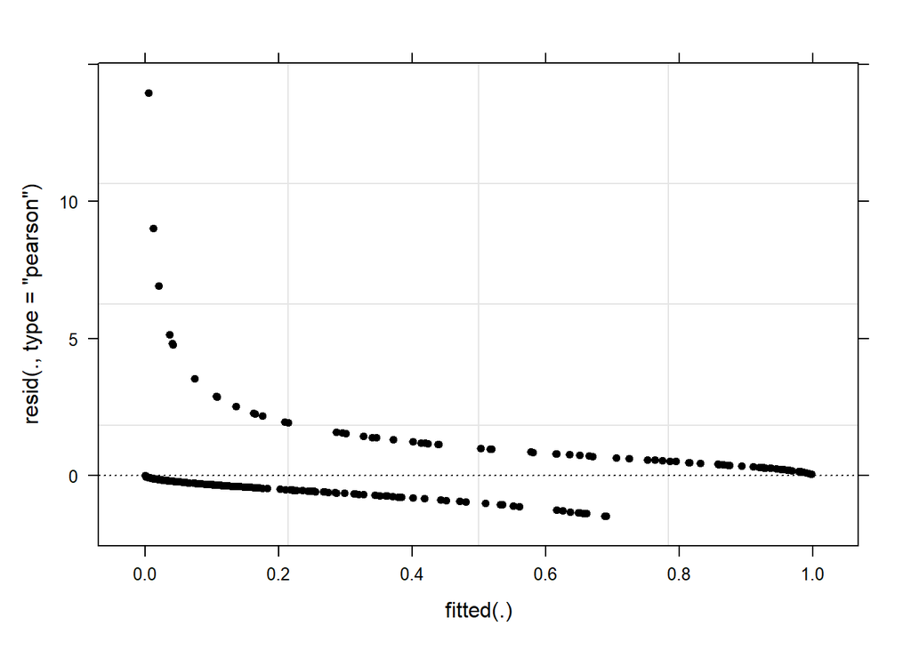

```r
plot(rs_lme_dur_tx, pch = 20, col = "black", lty = "dotted")
```

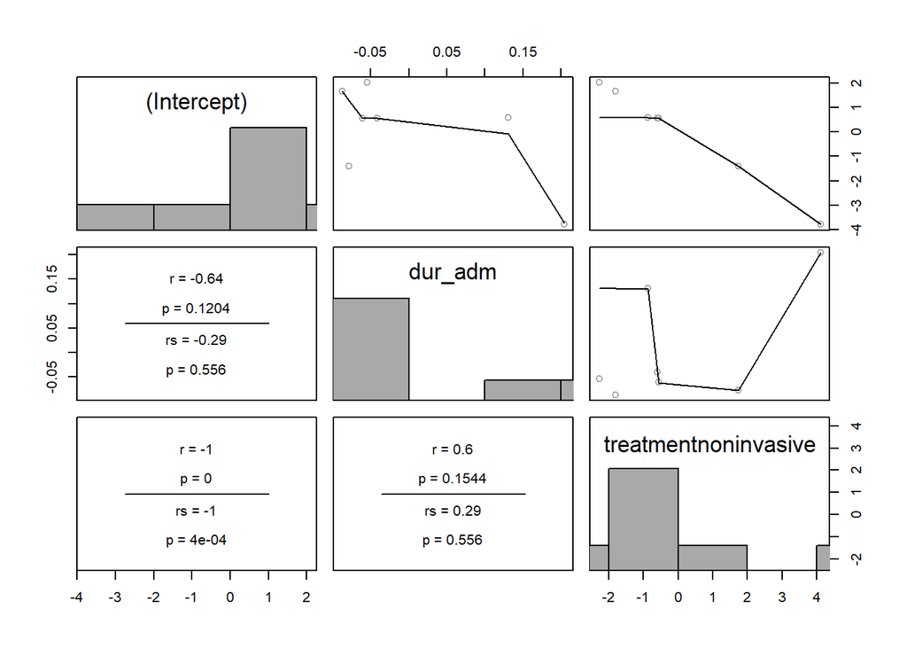

```r
library(languageR)
pairscor.fnc(ranef(rs_lme_dur_tx)$hospital)
```

AUROC

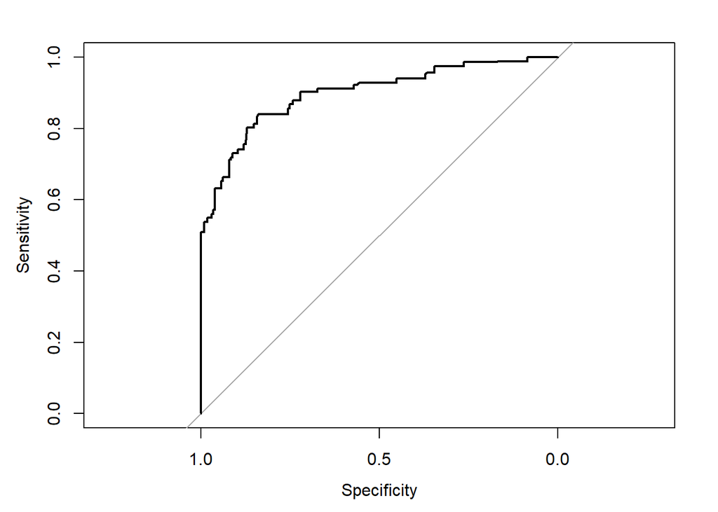

```r
library(pROC)
roc <- roc(response = data$status, predictor = fitted(rs_lme_dur_tx))
plot(roc)
```

```r
auc(roc)
```

```
Area under the curve: 0.8982
```

```r
ci(roc)
```

```
95% CI: 0.8769-0.9195 (DeLong)
```

```r
library(caret)
postMI <- factor(data$status, levels = c("0", "1"))

fit.m <- augment(rs_lme_dur_tx, type.predict = 'response') |>
           mutate(pred.class = factor(ifelse(.fitted > 0.5, '1', '0')))
fit.m$pred.class <- factor(fit.m$pred.class, levels = levels(postMI))

confusionMatrix(data = fit.m$pred.class, reference = postMI)
```

```
Confusion Matrix and Statistics

          Reference
Prediction   0   1
         0 846 117
         1  56 231

               Accuracy : 0.8616
                 95% CI : (0.8412, 0.8803)
    No Information Rate : 0.7216
    P-Value [Acc > NIR] : < 2.2e-16

                  Kappa : 0.6359

 Mcnemar's Test P-Value : 5.074e-06

            Sensitivity : 0.9379
            Specificity : 0.6638
         Pos Pred Value : 0.8785
         Neg Pred Value : 0.8049
             Prevalence : 0.7216
         Detection Rate : 0.6768
   Detection Prevalence : 0.7704
      Balanced Accuracy : 0.8009

       'Positive' Class : 0
```

## Presentation

### univariate analysis

```r
tbl_uvregression(data[c("status", "age", "sex", "dm", "ckd", "treatment", "dur_adm")], method = glm, y=status, method.args = list(family=binomial),estimate_fun = function(x) style_number(x, digits = 3), exponentiate = FALSE)
```

| **Characteristic** | **N** | **log(OR)**<sup>1</sup> | **95% CI**<sup>1</sup> | **p-value** |
| --- | --- | --- | --- | --- |
| age | 1,250 | 0.106 | 0.091, 0.121 | <0.001 |
| sex | 1,250 |  |  |  |
| female |  | — | — |  |
| male |  | 0.554 | 0.290, 0.823 | <0.001 |
| dm | 1,250 |  |  |  |
| no |  | — | — |  |
| yes |  | 1.163 | 0.890, 1.443 | <0.001 |
| ckd | 1,250 |  |  |  |
| no |  | — | — |  |
| yes |  | 0.818 | 0.566, 1.072 | <0.001 |
| treatment | 1,250 |  |  |  |
| invasive |  | — | — |  |
| noninvasive |  | 1.048 | 0.537, 1.624 | <0.001 |
| dur_adm | 1,250 | 0.204 | 0.170, 0.239 | <0.001 |

<sup>1</sup> OR = Odds Ratio, CI = Confidence Interval

### random effect

```r
# library(sjplot)
tab_model(rs_lme_dur_tx)
```

|  | status |  |  |
| --- | --- | --- | --- |
| Predictors | Odds Ratios | CI | p |
| (Intercept) | 0.00 | 0.00 – 0.00 | **<0.001** |
| age | 1.18 | 1.15 – 1.21 | **<0.001** |
| sex [male] | 3.25 | 2.16 – 4.90 | **<0.001** |
| dm [yes] | 2.99 | 2.03 – 4.39 | **<0.001** |
| ckd [yes] | 3.38 | 2.33 – 4.91 | **<0.001** |
| dur adm | 1.29 | 1.17 – 1.42 | **<0.001** |
| treatment [noninvasive] | 4.28 | 0.39 – 46.37 | 0.232 |
| Random Effects |  |  |  |
| σ<sup>2</sup> | 3.29 |  |  |
| τ<sub>00</sub> <sub>hospital</sub> | 4.60 |  |  |
| τ<sub>11</sub> <sub>hospital.dur_adm</sub> | 0.01 |  |  |
| τ<sub>11</sub> <sub>hospital.treatmentnoninvasive</sub> | 5.89 |  |  |
| ρ<sub>01</sub> | -0.44 |  |  |
|  | -1.00 |  |  |
| ICC | 0.25 |  |  |
| N <sub>hospital</sub> | 7 |  |  |
| Observations | 1250 |  |  |
| Marginal R<sup>2</sup> / Conditional R<sup>2</sup> | 0.555 / 0.668 |  |  |

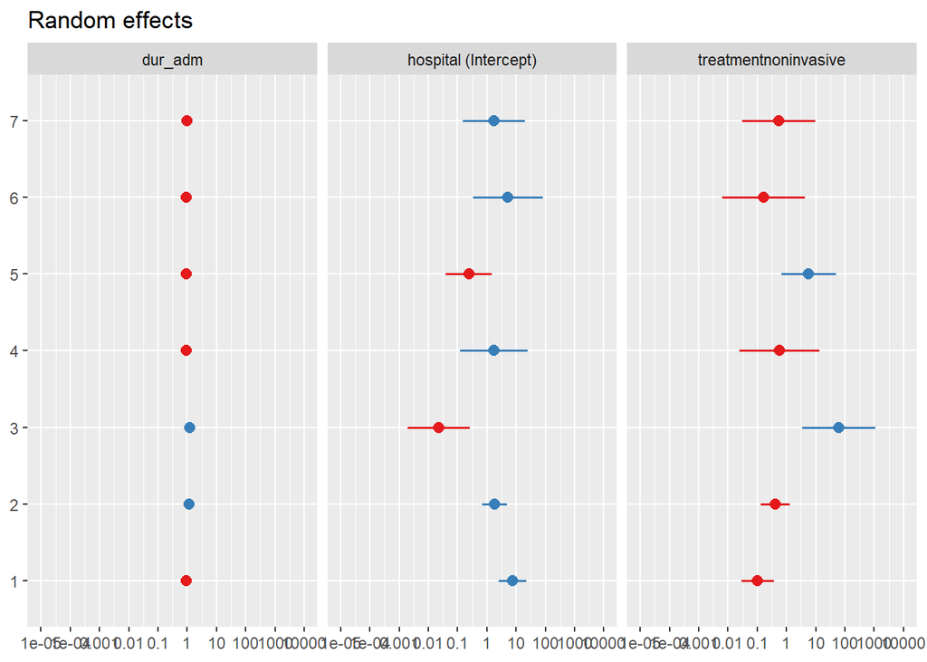

```r
plot_model(rs_lme_dur_tx, type = 're')
```

```r
# extract random effect
re_lme_dur_tx <- ranef(rs_lme_dur_tx)
cater_re_lme_dur_tx <- augment(re_lme_dur_tx)
```

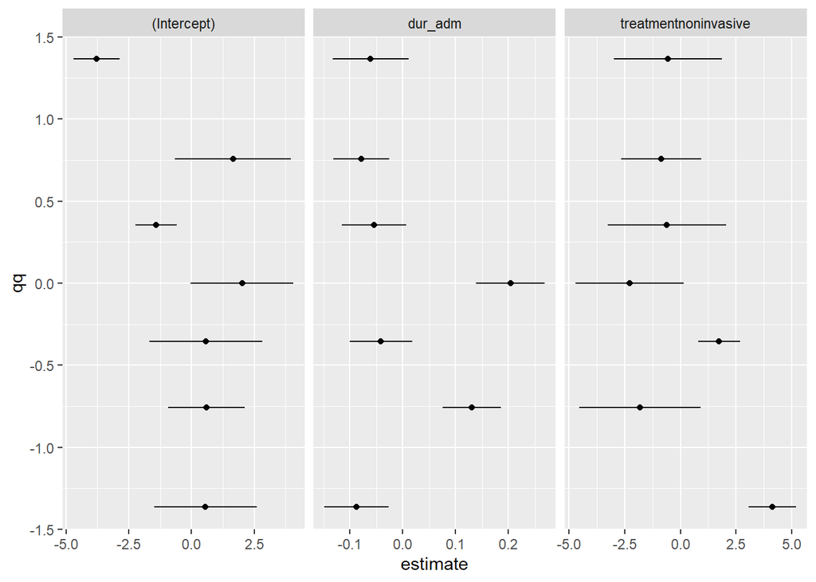

```r
ggplot(cater_re_lme_dur_tx, aes(estimate, qq, xmin = lb, xmax = ub))+
  geom_errorbarh(height=0) +
  geom_point() +
  facet_wrap(~variable,scale="free_x")
```

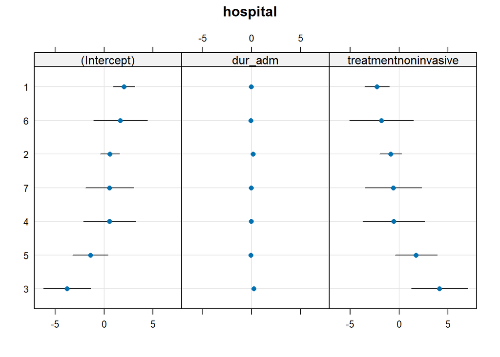

```r
lattice::dotplot(ranef(rs_lme_dur_tx, which = "hospital", condVar = TRUE))
```

table result

```r
tbl_regression(rs_lme_dur_tx, estimate_fun = function(x) style_number(x, digits = 3))
```

| **Characteristic** | **log(OR)**<sup>1</sup> | **95% CI**<sup>1</sup> | **p-value** |
| --- | --- | --- | --- |
| age | 0.168 | 0.144, 0.192 | <0.001 |
| sex |  |  |  |
| female | — | — |  |
| male | 1.179 | 0.768, 1.590 | <0.001 |
| dm |  |  |  |
| no | — | — |  |
| yes | 1.094 | 0.709, 1.479 | <0.001 |
| ckd |  |  |  |
| no | — | — |  |
| yes | 1.219 | 0.847, 1.591 | <0.001 |
| dur_adm | 0.255 | 0.157, 0.354 | <0.001 |
| treatment |  |  |  |
| invasive | — | — |  |
| noninvasive | 1.453 | -0.930, 3.837 | 0.2 |

<sup>1</sup> OR = Odds Ratio, CI = Confidence Interval

```r
tbl_regression(rs_lme_dur_tx, exp =T, estimate_fun = function(x) style_number(x, digits = 3))
```

| **Characteristic** | **OR**<sup>1</sup> | **95% CI**<sup>1</sup> | **p-value** |
| --- | --- | --- | --- |
| age | 1.183 | 1.155, 1.211 | <0.001 |
| sex |  |  |  |
| female | — | — |  |
| male | 3.252 | 2.156, 4.905 | <0.001 |
| dm |  |  |  |
| no | — | — |  |
| yes | 2.987 | 2.032, 4.389 | <0.001 |
| ckd |  |  |  |
| no | — | — |  |
| yes | 3.384 | 2.333, 4.910 | <0.001 |
| dur_adm | 1.291 | 1.170, 1.425 | <0.001 |
| treatment |  |  |  |
| invasive | — | — |  |
| noninvasive | 4.278 | 0.395, 46.367 | 0.2 |

<sup>1</sup> OR = Odds Ratio, CI = Confidence Interval

plot predicted probabilities

```r
age <-plot_model(rs_lme_dur_tx, type = "pred", terms = c("age"), axis.labels = NULL)
```

```
Data were 'prettified'. Consider using `terms="age [all]"` to get smooth
  plots.
```

```r
sex <-plot_model(rs_lme_dur_tx, type = "pred", terms = c("sex"), title = NULL)
dm <-plot_model(rs_lme_dur_tx, type = "pred", terms = c("dm"), title = NULL)
ckd <-plot_model(rs_lme_dur_tx, type = "pred", terms = c("ckd"), title = NULL)
dur <-plot_model(rs_lme_dur_tx, type = "pred", terms = c("dur_adm"), title = NULL)
tx <- plot_model(rs_lme_dur_tx, type = "pred", terms = c("treatment"), title = NULL)
```

```r
age <- age + ggtitle(NULL)
sex <- sex + ggtitle(NULL)
dm <- dm + ggtitle(NULL)
ckd <- ckd + ggtitle(NULL)
dur <- dur + ggtitle(NULL)
tx <- tx + ggtitle(NULL)
```

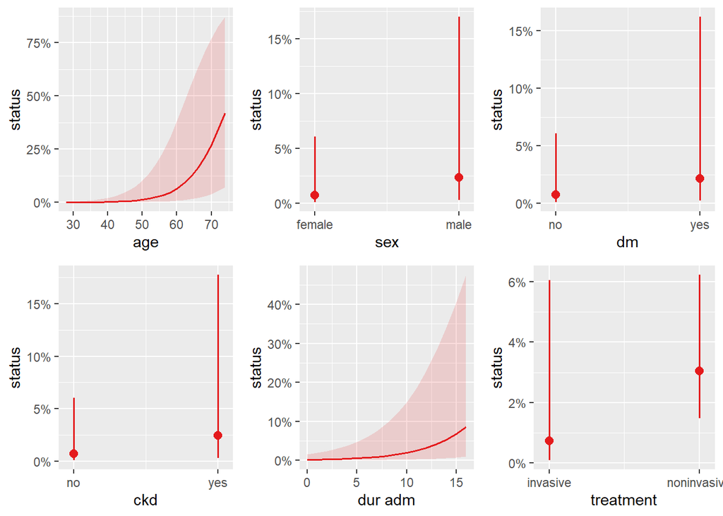

```r
grid.arrange(age, sex, dm, ckd, dur, tx, ncol=3)
```

report

```r
report::report(rs_lme_dur_tx)
```

```
We fitted a logistic mixed model (estimated using ML and Nelder-Mead optimizer)
to predict status with age, sex, dm, ckd, dur_adm and treatment (formula:
status ~ age + sex + dm + ckd + dur_adm + treatment). The model included
dur_adm as random effects (formula: ~1 + dur_adm + treatment | hospital). The
model's total explanatory power is substantial (conditional R2 = 0.67) and the
part related to the fixed effects alone (marginal R2) is of 0.56. The model's
intercept, corresponding to age = 0, sex = female, dm = no, ckd = no, dur_adm =
0 and treatment = invasive, is at -14.27 (95% CI [-16.93, -11.62], p < .001).
Within this model:

  - The effect of age is statistically significant and positive (beta = 0.17, 95%
CI [0.14, 0.19], p < .001; Std. beta = 1.57, 95% CI [1.35, 1.80])
  - The effect of sex [male] is statistically significant and positive (beta =
1.18, 95% CI [0.77, 1.59], p < .001; Std. beta = 1.17, 95% CI [0.76, 1.58])
  - The effect of dm [yes] is statistically significant and positive (beta =
1.09, 95% CI [0.71, 1.48], p < .001; Std. beta = 1.09, 95% CI [0.71, 1.48])
  - The effect of ckd [yes] is statistically significant and positive (beta =
1.22, 95% CI [0.85, 1.59], p < .001; Std. beta = 1.21, 95% CI [0.84, 1.59])
  - The effect of dur adm is statistically significant and positive (beta = 0.26,
95% CI [0.16, 0.35], p < .001; Std. beta = 1.01, 95% CI [0.62, 1.40])
  - The effect of treatment [noninvasive] is statistically non-significant and
positive (beta = 1.45, 95% CI [-0.93, 3.84], p = 0.232; Std. beta = 1.61, 95%
CI [-0.97, 4.19])

Standardized parameters were obtained by fitting the model on a standardized
version of the dataset. 95% Confidence Intervals (CIs) and p-values were
computed using a Wald z-distribution approximation.
```